# Exploring Carabid Beetle and Spider Diversity, Community Composition and Functional Traits Across Vineyard and Semi-Natural Habitats

Hannah Friesen

2026-03-24

## 1 System Info

```r
version
```

```
##                _
## platform       x86_64-w64-mingw32
## arch           x86_64
## os             mingw32
## crt            ucrt
## system         x86_64, mingw32
## status
## major          4
## minor          5.2
## year           2025
## month          10
## day            31
## svn rev        88974
## language       R
## version.string R version 4.5.2 (2025-10-31 ucrt)
## nickname       [Not] Part in a Rumble
```

## 2 Set up

### 2.1 Loading Packages

```r
# Load necessary libraries
library(dplyr)
library(ggplot2)
library(tidyr)
library(stringr)
library(vegan)
library(tibble)
library(purrr)
library(gllvm)
library(corrplot)
library(ggvenn)
library(iNEXT)
library(lattice)


## Citing packages
grateful::cite_packages(
  output = "file",
  out.dir = here::here("01_analysis")
)
```

[output not shown]

[output not shown]

```
## [1] "C:/Personal/R/VY_BIO_SNH/01_analysis/grateful-report.html"
```

## 3 CONTEXT

This research is exploratory and observational.

### 3.1 Objective

The aim of this research is to characterize carabid beetle and spider communities in vineyard agroecosystems and adjacent SNH in the Okanagan Valley. Specifically, this study explores how carabid beetle and spider diversity and community composition vary between vineyard and SNH, and if functional traits explain any of the variation.

## 4 SPIDERS

### 4.1 Data import and pre-processing

Let’s import the raw spider data and summarize by site/ habitat/ year. We will filter out field margin samples from the main analysis as they were not sampled in 2025. September samples were excluded due to low trap recovery.

Let’s also calculate the total number of spiders collected, and the number of different families. Note that spiders that could not be identified to family level, either due to damage or being juveniles, are included in total spider count but not in family richness count.

```r
# Load spider data
spider_habitat_df <- read.csv(here::here("00_data","spider_habitat_df.csv"))

# Filter out field margins and september data from the main analysis
spider_habitat_df <- spider_habitat_df %>%
  filter(
    subhabitat != "FM",
    sample_period != "SEP"
  )

# Identify family columns from descriptor columns
family_cols <- setdiff(names(spider_habitat_df), c("pitfall_ID", "year", "habitat", "subhabitat", "family_richness", "sample_period", "site_ID", "year_established", "total_count"))

# ensure family cols are integer counts
spider_habitat_df <- spider_habitat_df %>%
  mutate(across(all_of(family_cols), ~ as.integer(tidyr::replace_na(.x, 0L))))

# Then re-define unid and identified categories
unid_cols <- union("UNID.", "LYCOSIDAE..juvenile.")  # add the juvenile manually
family_columns <- setdiff(family_cols, unid_cols)

# Summarize spider abundance by site_ID, habitat, sample period and year
spider_habitat_summary <- spider_habitat_df %>%
  group_by(site_ID, habitat, sample_period, year) %>%
  summarise(
    across(all_of(family_cols), ~ sum(.x, na.rm = TRUE)),
    trap_count = n(),     # destroyed traps already removed earlier
    .groups = "drop"
  )

# Total number of spiders found in vineyards across all sites and years (including juveniles/ UNID)
total_spiders <- sum(spider_habitat_df$total_count, na.rm = TRUE)

# total number of traps
total_traps <- spider_habitat_summary %>%
  summarise(total_traps = sum(trap_count, na.rm = TRUE)) %>%
  pull(total_traps)

# Convert wide data (family columns) into long format
spider_long_habitat <- spider_habitat_df %>%
  pivot_longer(cols = all_of(family_columns), names_to = "spider_family", values_to = "count") %>%
  drop_na(count) %>%  # Remove missing values
  filter(count >= 0)  # Ensure only observed families are counted

# Get a list of all families observed at least once
observed_families_habitat <- spider_long_habitat %>%
  filter(count > 0) %>%
  distinct(spider_family) %>%
  arrange(spider_family)

# View the result
print(observed_families_habitat)
```

```
## # A tibble: 23 × 1
##    spider_family
##    <chr>
##  1 AGELENIDAE
##  2 AMAUROBIIDAE
##  3 ANTRODIAETIDAE
##  4 ARANEIDAE
##  5 CHEIRACANTHIIDAE
##  6 CLUBIONIDAE
##  7 CORINNIDAE
##  8 CYBAEIDAE
##  9 DICTYNIDAE
## 10 GNAPHOSIDAE
## # ℹ 13 more rows
```

```r
# calculate relative abundance of each spider family
spider_family_rel <- spider_long_habitat %>%
  group_by(spider_family) %>%
  summarise(n = sum(count, na.rm = TRUE), .groups = "drop") %>%
  mutate(rel_abund = n / sum(n)) %>%   # relative abundance within each habitat
  ungroup() %>%
  filter(n > 0)

spider_family_rel
```

| spider_family | n | rel_abund |
| --- | --- | --- |
| AGELENIDAE | 97 | 0.0148431523 |
| AMAUROBIIDAE | 4 | 0.0006120888 |
| ANTRODIAETIDAE | 3 | 0.0004590666 |
| ARANEIDAE | 1 | 0.0001530222 |
| CHEIRACANTHIIDAE | 1 | 0.0001530222 |
| CLUBIONIDAE | 7 | 0.0010711553 |
| CORINNIDAE | 20 | 0.0030604438 |
| CYBAEIDAE | 7 | 0.0010711553 |
| DICTYNIDAE | 64 | 0.0097934200 |
| GNAPHOSIDAE | 585 | 0.0895179801 |

[output cut: 13 more lines]

```r
# calculate sample size
habitat_n <- spider_habitat_summary %>%
  group_by(habitat) %>%
  summarise(n = n(), .groups = "drop")

habitat_n
```

| habitat | n |
| --- | --- |
| SNH | 45 |
| VY | 45 |

```r
# sample size by year
habitat_n_year <- spider_habitat_summary %>%
  group_by(year, habitat) %>%
  summarise(n = n(), .groups = "drop")

habitat_n_year
```

| year | habitat | n |
| --- | --- | --- |
| 2024 | SNH | 14 |
| 2024 | VY | 14 |
| 2025 | SNH | 31 |
| 2025 | VY | 31 |

```r
cat("Total spiders in all habitats across all sites and years:", total_spiders, "\n")
```

```
## Total spiders in all habitats across all sites and years: 7070
```

```r
cat(
  "Total number of observed families in all habitats across all sites and years:",
  nrow(observed_families_habitat),
  "\n"
)
```

```
## Total number of observed families in all habitats across all sites and years: 23
```

```r
cat("Total traps in all habitats across all sites and years:", total_traps, "\n")
```

```
## Total traps in all habitats across all sites and years: 520
```

```r
cat("Number of site × habitat × year combinations:", nrow(spider_habitat_summary), "\n")
```

```
## Number of site × habitat × year combinations: 90
```

### 4.2 Summary table

```r
# table summarizing spider family abundance by habitat/ year
spider_family_table <- spider_long_habitat %>%
  group_by(spider_family, habitat, year) %>%
  summarise(
    total_abundance = sum(count, na.rm = TRUE),
    .groups = "drop"
  ) %>%
  unite(habitat_year, habitat, year) %>%
  pivot_wider(
    names_from  = habitat_year,
    values_from = total_abundance,
    values_fill = 0
  ) %>%
  mutate(Total = rowSums(across(where(is.numeric)))) %>%
  arrange(desc(Total))

# make labels little letters for clarity
spider_family_table <- spider_family_table %>%
  mutate(spider_family = stringr::str_to_title(spider_family))

spider_family_table
```

| spider_family | SNH_2024 | SNH_2025 | VY_2024 | VY_2025 | Total |
| --- | --- | --- | --- | --- | --- |
| Zodariidae | 149 | 549 | 394 | 1398 | 2490 |
| Lycosidae | 223 | 517 | 262 | 640 | 1642 |
| Linyphiidae | 5 | 42 | 142 | 520 | 709 |
| Gnaphosidae | 65 | 165 | 135 | 220 | 585 |
| Thomisidae | 21 | 160 | 29 | 165 | 375 |
| Phrurolithidae | 29 | 240 | 1 | 22 | 292 |
| Theridiidae | 5 | 70 | 10 | 37 | 122 |
| Agelenidae | 11 | 53 | 3 | 30 | 97 |
| Salticidae | 4 | 38 | 8 | 21 | 71 |
| Dictynidae | 0 | 19 | 7 | 38 | 64 |

[output cut: 20 more lines]

```r
# save as table
write.csv(
  spider_family_table,
  here::here("02_tables", "spider_family_table.csv"),
  row.names = FALSE
)
```

### 4.3 Sample Coverage and Hill Diversity

Let’s use iNEXT to evaluate sampling completeness (sample coverage) and calculate hill diversity (richness, shannon and simpson). Use only adult family counts (not juveniles and unidentified species)

```r
custom_colors <- c("VY"="#8E44AD","SNH"="#009E73")

#  Summarize by habitat
spider_by_habitat <- spider_habitat_summary %>%
  group_by(habitat) %>%
  summarise(across(all_of(family_columns), ~ sum(.x, na.rm = TRUE)),
            .groups = "drop")

# Build iNEXT list: named abundance vectors (one per habitat)
spider_list_habitat <- setNames(
  lapply(seq_len(nrow(spider_by_habitat)), function(i) {
    v <- unlist(spider_by_habitat[i, family_columns], use.names = TRUE)
    v[is.na(v)] <- 0
    v
  }),
  spider_by_habitat$habitat
)

# Sample coverage + totals
spider_coverage <- DataInfo(spider_list_habitat, datatype = "abundance")

spider_coverage
```

| Assemblage | n | S.obs | SC | f1 | f2 | f3 | f4 | f5 | f6 | f7 | f8 | f9 | f10 |
| --- | --- | --- | --- | --- | --- | --- | --- | --- | --- | --- | --- | --- | --- |
| SNH | 2436 | 22 | 0.9992 | 2 | 1 | 3 | 1 | 0 | 0 | 2 | 0 | 0 | 1 |
| VY | 4099 | 16 | 0.9998 | 1 | 1 | 3 | 0 | 1 | 0 | 0 | 0 | 0 | 0 |

```r
# Hill numbers
spider_hill <- iNEXT(spider_list_habitat, q = c(0, 1, 2), datatype = "abundance")

spider_hill_diversity<- spider_hill$AsyEst

spider_hill_diversity
```

| Assemblage | Diversity | Observed | Estimator | s.e. | LCL | UCL |
| --- | --- | --- | --- | --- | --- | --- |
| SNH | Species richness | 22.000000 | 23.999179 | 3.84167983 | 22.000000 | 31.528733 |
| SNH | Shannon diversity | 6.906559 | 6.940797 | 0.16300134 | 6.621320 | 7.260273 |
| SNH | Simpson diversity | 4.914015 | 4.921927 | 0.11408944 | 4.698316 | 5.145538 |
| VY | Species richness | 16.000000 | 16.499878 | 2.14238608 | 16.000000 | 20.698878 |
| VY | Shannon diversity | 4.850399 | 4.859983 | 0.08100543 | 4.701216 | 5.018751 |
| VY | Simpson diversity | 3.626140 | 3.628465 | 0.06444254 | 3.502160 | 3.754770 |

```r
# save as csv
write.csv(
  spider_hill_diversity,
  here::here("02_tables", "spider_hill_diversity.csv"),
  row.names = FALSE
)
```

Sample completeness very high for both VY and SNH (>0.99). Likely so high because we are evaluating at the family level (coarse taxonomic resolution), only a few singletons/ doubletons in each habitat.

Higher observed and estimated richness in SNH (22) compared to VY (16). Pretty high confidence for both Also higher shannon and simpson diversity in SNH’s. indicates more evenness in SNH’s compared to VY’s.

Let’s make some curves for the sample coverage and hill diversity metrics

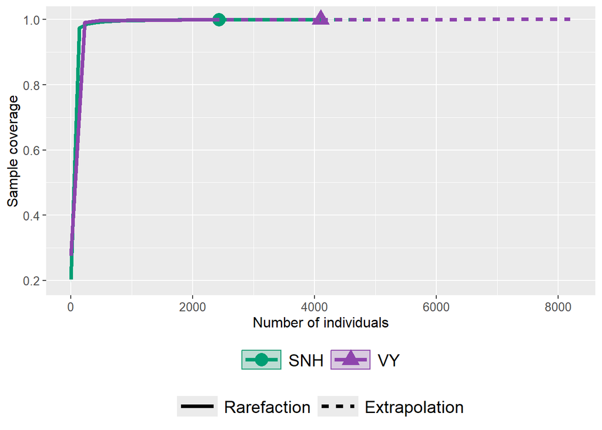

```r
# Coverage-based curves
spider_sample_coverage <- ggiNEXT(spider_hill, type = 2) +
  scale_colour_manual(values = custom_colors) +
  scale_fill_manual(values = custom_colors) +
  theme(
    legend.title = element_blank(),
    axis.title  = element_text(size = 12),
    axis.text   = element_text(size = 10)
  )

spider_sample_coverage
```

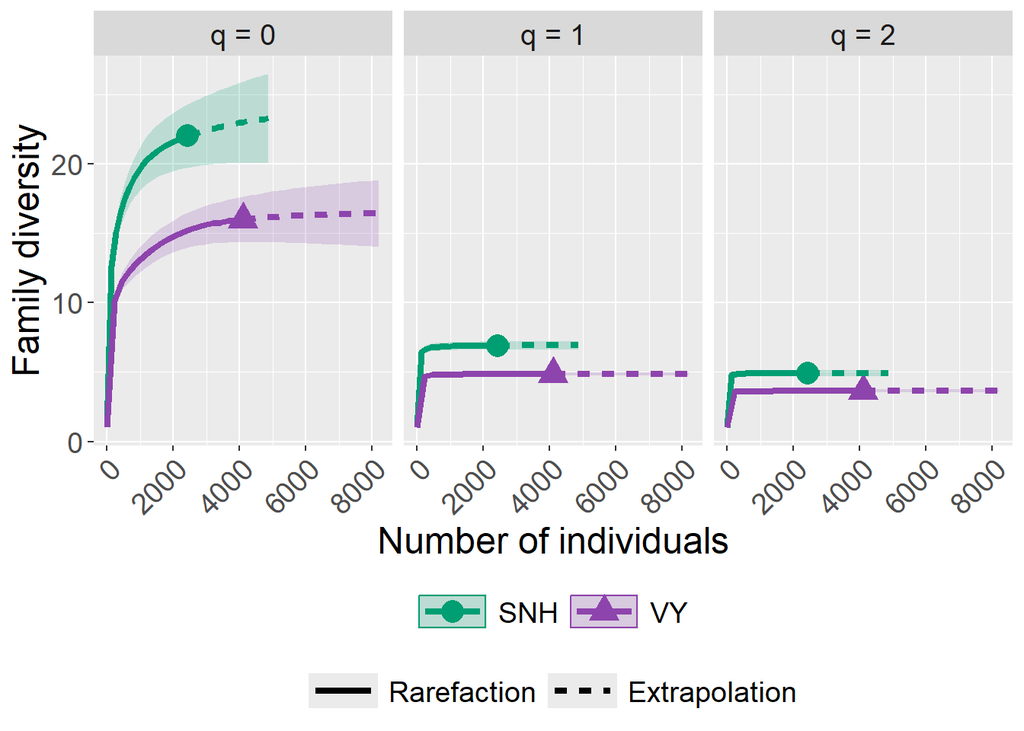

```r
# sample size based Hill curves
spider_hill_size <- ggiNEXT(spider_hill, type = 1,
  facet.var = "Order.q") +
  scale_colour_manual(values = custom_colors) +
  scale_fill_manual(values = custom_colors) +
  labs(
    x = "Number of individuals",
    y = "Family diversity"
  ) +
  theme(
    axis.text.x = element_text(angle = 45, hjust = 1)
  )



spider_hill_size
```

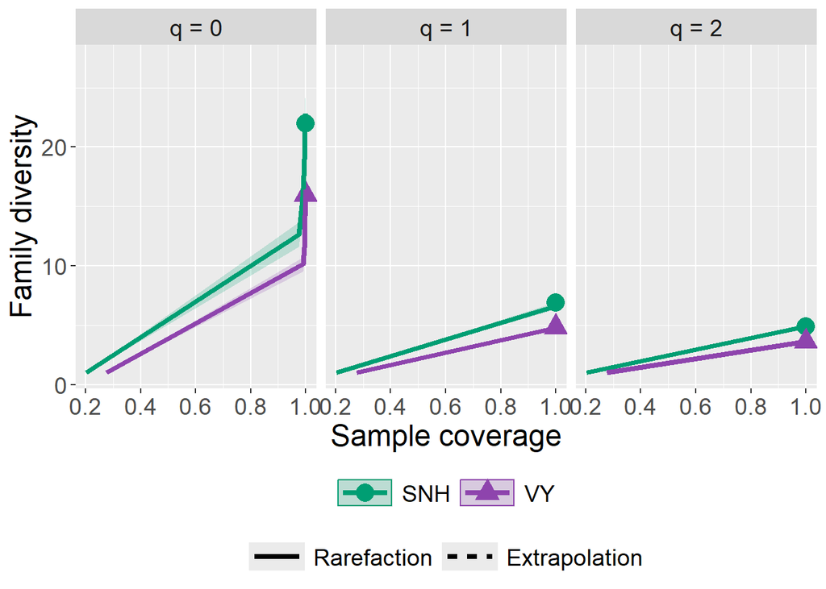

```r
# Coverage-based Hill curves
spider_hill_coverage <- ggiNEXT(spider_hill, type = 3,
  facet.var="Order.q") +
  scale_colour_manual(values = custom_colors) +
  scale_fill_manual(values = custom_colors) +
  labs(
    x = "Sample coverage",
    y = "Family diversity"
  )

spider_hill_coverage
```

### 4.4 Data Exploration

This section explores spiders by habitat type

#### 4.4.1 Relative abundance plots

This section uses a bubble plot to visualize spider family relative abundance by habitat type

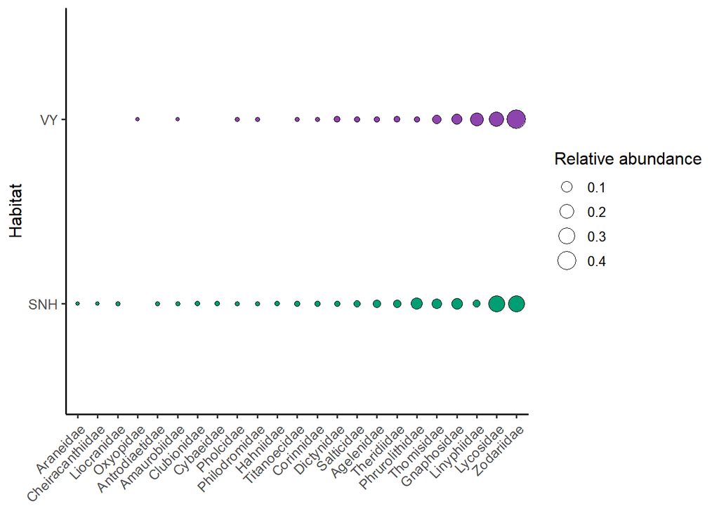

```r
custom_colors <- c("VY"="#8E44AD","SNH"="#009E73")

# 1) Summarise total individuals per habitat x family
spider_family_habitat_rel <- spider_long_habitat %>%
  group_by(habitat, spider_family) %>%
  summarise(n = sum(count, na.rm = TRUE), .groups = "drop") %>%
  group_by(habitat) %>%
  mutate(rel_abund = n / sum(n)) %>%   # relative abundance within each habitat
  ungroup() %>%
  filter(n > 0)


# make labels little letters for clarity
spider_family_habitat_rel <- spider_family_habitat_rel %>%
  mutate(spider_family = stringr::str_to_title(spider_family))

# 2) Order families (overall abundance across all habitats)
family_order <- spider_family_habitat_rel %>%
  group_by(spider_family) %>%
  summarise(total_n = sum(n), .groups = "drop") %>%
  arrange(total_n) %>%
  pull(spider_family)

spider_family_habitat_rel <- spider_family_habitat_rel %>%
  mutate(spider_family = factor(spider_family, levels = family_order))


# 3) Bubble plot of relative abundance of each family by habitat type
spider_relative_abundance <- ggplot(spider_family_habitat_rel,
       aes(x = spider_family, y = habitat,
           size = rel_abund, fill = habitat)) +
  geom_point(shape = 21, color = "black", alpha = 1) +
  scale_size_continuous(name = "Relative abundance") +
  scale_fill_manual(values = custom_colors) +
  labs(x = NULL, y = "Habitat") +
  theme_classic(base_size = 12) +
  theme(
    axis.text.x = element_text(angle = 45, hjust = 1),
    legend.position = "right"
  ) +
  guides(fill = "none")


spider_relative_abundance
```

#### 4.4.2 Abundance and richness by habitat

This section uses boxplots to look at the mean abundance per trap and rarefied richness

```r
# define custom colors
custom_colors <- c("VY"="#8E44AD","SNH"="#009E73")

# -----------------------------
# HABITAT ABUNDACE, family RICHNESS, MEAN PER TRAP AND RAREFIED RICHNESS
# -----------------------------
# ALL HABITATS RICHNESS
fam_mat            <- as.matrix(dplyr::select(spider_habitat_summary, all_of(family_columns)))
total_abundance   <- rowSums(fam_mat)
family_richness  <- rowSums(fam_mat > 0)

#   Use the minimum total individuals among groups with > min_m_individuals
min_m_individuals <- 20L
m_candidates      <- total_abundance[total_abundance > min_m_individuals]

rarefaction_m <- if (length(m_candidates)) min(m_candidates) else NA_integer_

# Rarefy (individual-based); NA if m not available
rarefied_richness <- if (is.na(rarefaction_m)) {
  rep(NA_real_, nrow(fam_mat))
} else {
  vegan::rarefy(fam_mat, sample = rarefaction_m)
}

# Assemble final summary table
spider_habitat_data <- spider_habitat_summary %>%
  dplyr::select(site_ID, habitat, sample_period, year, trap_count) %>%
  mutate(
    total_abundance   = total_abundance,
    mean_per_trap     = ifelse(trap_count > 0, total_abundance / trap_count, NA_real_),
    family_richness  = family_richness,
    rarefied_richness = rarefied_richness,
    rarefaction_m     = rarefaction_m
  ) %>%
  arrange(site_ID, year, sample_period, habitat)

# calculate mean per trap by habitat
spider_mean_by_habitat <- spider_habitat_data %>%
  dplyr::group_by(habitat) %>%
  dplyr::summarise(
    mean_per_trap = mean(mean_per_trap, na.rm = TRUE),
    n             = dplyr::n(),
    .groups = "drop"
  )
spider_mean_by_habitat
```

| habitat | mean_per_trap | n |
| --- | --- | --- |
| SNH | 10.17222 | 45 |
| VY | 15.30963 | 45 |

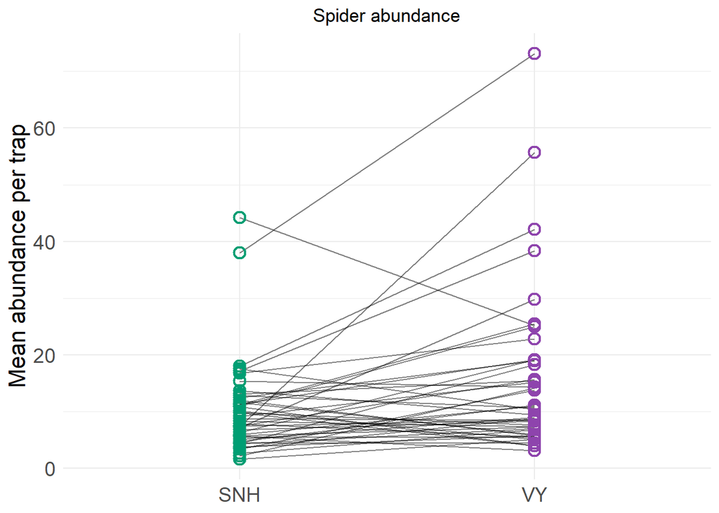

```r
# plot mean abundance per trap by Habitat (VY/ SNH)
# lets use line plots to account for paired design (each site has a VY and SNH)
# we're using mean per plot instead of total abundance to account for traps lost in the field
spider_abundance_line <- ggplot(
  spider_habitat_data,
  aes(
    x = habitat,
    y = mean_per_trap,
    group = interaction(site_ID, year)
  )
) +
  # paired lines in grey
  geom_line(
    color = "black",
    alpha = 0.5
  ) +
  # points coloured by habitat
  geom_point(
    aes(color = habitat),
    shape = 21,
    size = 3,
    stroke = 1.2
  ) +
  scale_color_manual(values = custom_colors) +
  scale_fill_manual(values = custom_colors) +
  labs(
    title = "Spider abundance",
    x = NULL,
    y = "Mean abundance per trap"
  ) +
  theme_minimal() +
  theme(
    plot.title = element_text(hjust = 0.5),
    legend.position = "none"
  ) + theme(
  axis.text.x  = element_text(size = 14),
  axis.text.y  = element_text(size = 14),
  axis.title.y = element_text(size = 16)
)


spider_abundance_line
```

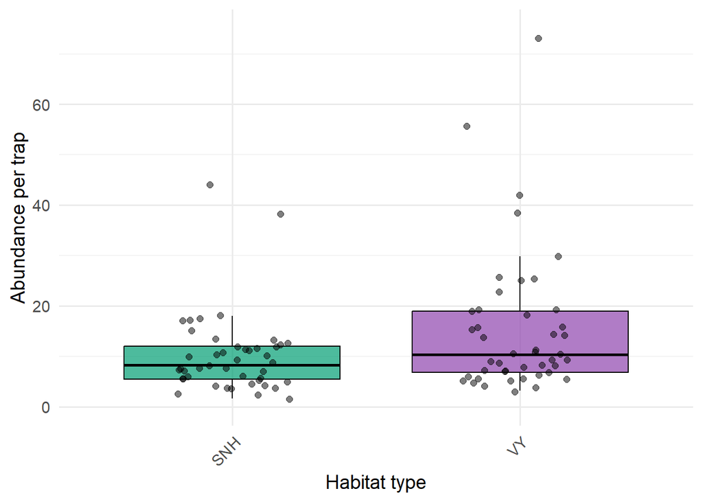

```r
# plots mean per trap by Habitat (VY/ SNH)
spider_mean_abundance <- ggplot(spider_habitat_data, aes(x = habitat, y = mean_per_trap, fill = habitat)) +
  geom_boxplot(outlier.shape = NA, alpha = 0.7, color = "black") +
  geom_jitter(width = 0.2, height = 0.3, alpha = 0.5, size = 2, color = "black")+
  coord_cartesian(ylim = c(0, 75)) +
  labs(
    x = "Habitat type",
    y = "Abundance per trap"
  ) +
  theme_minimal(base_size = 14) +
  scale_fill_manual(values = custom_colors) +
  theme(
    legend.position = "none",
    plot.title = element_text(face = "bold", hjust = 0.5),
    axis.text.x = element_text(angle = 45, hjust = 1)
  )

spider_mean_abundance
```

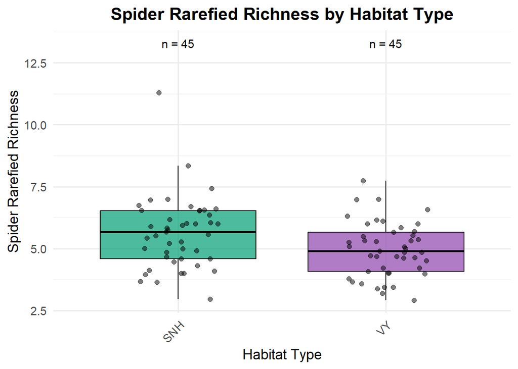

```r
# plot rarefied richness
spider_rarefied_richness <-ggplot(spider_habitat_data, aes(x = habitat, y = rarefied_richness, fill = habitat)) +
  geom_boxplot(outlier.shape = NA, alpha = 0.7, color = "black") +
  geom_jitter(width = 0.2, alpha = 0.5, size = 2, color = "black") +
  geom_text(
    data = habitat_n,
    aes(
      x = habitat,
      y = max(spider_habitat_data$rarefied_richness, na.rm = TRUE) + 2,
      label = paste0("n = ", n)
    ),
    inherit.aes = FALSE,
    size = 4
  ) +
  labs(
    title = "Spider Rarefied Richness by Habitat Type",
    x = "Habitat Type",
    y = "Spider Rarefied Richness"
  ) +
  theme_minimal(base_size = 14) +
  scale_fill_manual(values = custom_colors) +
  theme(
    legend.position = "none",
    plot.title = element_text(face = "bold", hjust = 0.5),
    axis.text.x = element_text(angle = 45, hjust = 1))

spider_rarefied_richness
```

Vineyards generally have higher mean abundance, but a little lower (rarefied) richness

#### 4.4.3 Venn diagrams by habitat

This section uses venn diagrams to visualize the distribution of families by habitat

```r
# Presence-absence by subhabitat
spider_presence <- spider_habitat_df %>%
  dplyr::select(all_of(family_columns), habitat) %>%
  group_by(habitat) %>%
  summarise(across(where(is.numeric), ~ sum(.x > 0) > 0))

# Create lists of spider families present in each habitat
spider_families_by_habitat <- lapply(split(spider_presence, spider_presence$habitat), function(df) {
  names(df)[which(as.logical(df[-1])) + 1]  # Skip habitat column
})

spider_families_by_habitat
```

```
## $SNH
##  [1] "AGELENIDAE"       "AMAUROBIIDAE"     "ANTRODIAETIDAE"   "ARANEIDAE"        "CHEIRACANTHIIDAE" "CLUBIONIDAE"      "CORINNIDAE"       "CYBAEIDAE"        "DICTYNIDAE"       "GNAPHOSIDAE"      "HAHNIIDAE"        "LINYPHIIDAE"      "LIOCRANIDAE"      "LYCOSIDAE"        "PHILODROMIDAE"    "PHOLCI…
##
## $VY
##  [1] "AGELENIDAE"     "AMAUROBIIDAE"   "CORINNIDAE"     "DICTYNIDAE"     "GNAPHOSIDAE"    "LINYPHIIDAE"    "LYCOSIDAE"      "OXYOPIDAE"      "PHILODROMIDAE"  "PHOLCIDAE"      "PHRUROLITHIDAE" "SALTICIDAE"     "THERIDIIDAE"    "THOMISIDAE"     "TITANOECIDAE"   "ZODARIIDAE"
```

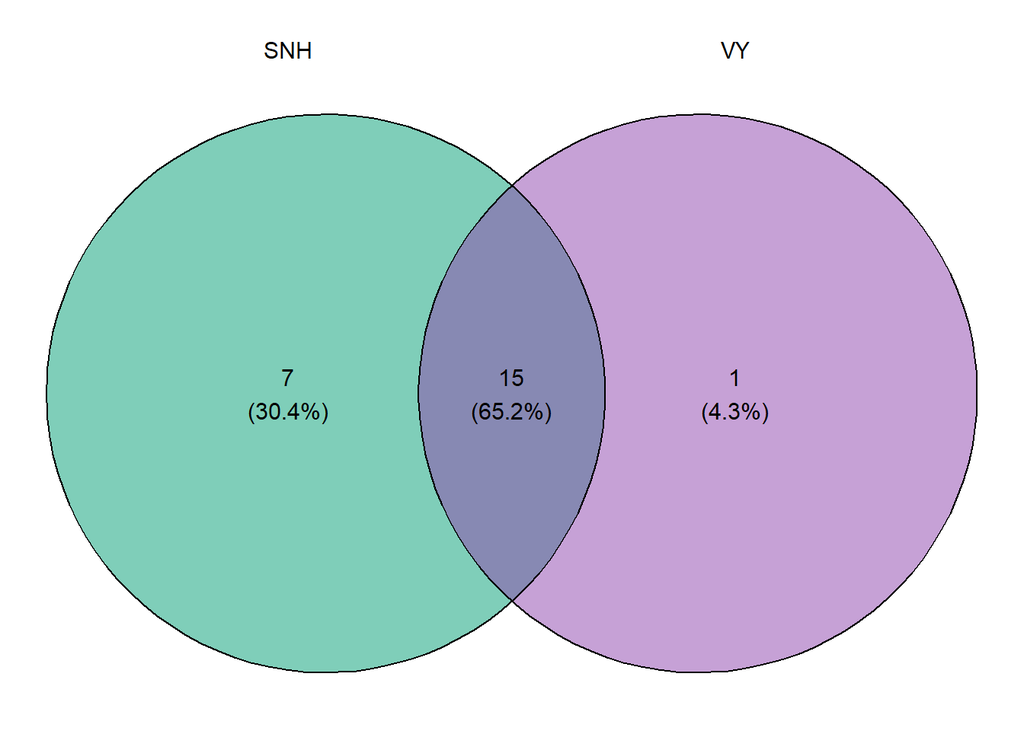

```r
# plot as a venn diagram
ggvenn_spider_families <- ggvenn(spider_families_by_habitat,
       fill_color = c("#009E73", "#8E44AD"),
       stroke_size = 0.5,
       set_name_size = 4)

ggvenn_spider_families
```

15 spider families found in both habitats, 1 found only in VY and 7 found only in SNH

#### 4.4.4 Spider traits by habitat

This section explores uses barplots and pie charts to explore spider traits/ guilds by habitat type.

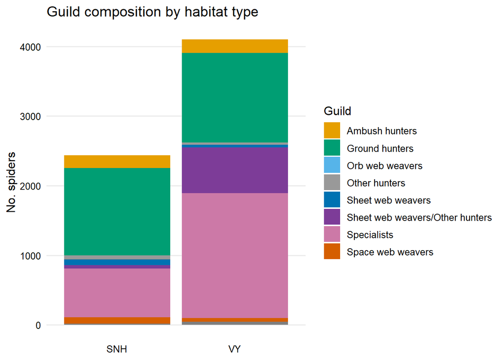

```r
# upload the spider traits data
spider_traits <- read.csv(here::here ("00_data", "spider_family_traits.csv"))

# join to spider habitat data (in long format)
spider_long_traits_habitat <- spider_long_habitat %>%
  dplyr::left_join(
    dplyr::select(spider_traits, spider_family, guild_code),
    by = "spider_family"
  )

# summarize guild abundance by site_ID, habitat and year
guild_abundance_habitat <- spider_long_traits_habitat %>%
  group_by(site_ID, habitat, year, guild_code) %>%
  summarise(total_abundance = sum(count), .groups = "drop")

# pivot to wide format
guild_abundance_wide <- guild_abundance_habitat %>%
  pivot_wider(
    names_from = guild_code,
    values_from = total_abundance,
    values_fill = 0  # fill missing combinations with 0
  )

# Make sure guild_abundance_habitat is prepared
guild_abundance_plot <- guild_abundance_habitat %>%
  group_by(habitat, guild_code) %>%
  summarise(total_abundance = sum(total_abundance), .groups = "drop")
guild_abundance_plot <- guild_abundance_plot %>%
  filter(!is.na(guild_code))


# Custom colors (edit to match your desired palette)
guild_colors <- c(
  "AMH" = "#E69F00",     # orange
  "GRH" = "#009E73",     # bluish green
  "ORW" = "#56B4E9",     # sky blue
  "SHW" = "#0072B2",     # blue
  "SPW" = "#D55E00",     # vermillion
  "SPE" = "#CC79A7",     # reddish purple
  "OTH" = "#999999",     # grey
  "SHW/ GRH" = "#F0E442", # yellow
  "SHW/ OTH" = "#7D3C98"  # black
)

guild_labels <- c(
  "AMH" = "Ambush hunters",
  "GRH" = "Ground hunters",
  "ORW" = "Orb web weavers",
  "SHW" = "Sheet web weavers",
  "SPW" = "Space web weavers",
  "SPE" = "Specialists",
  "OTH" = "Other hunters",
  "SHW/ GRH" = "Sheet web weavers/Ground hunters",
  "SHW/ OTH" = "Sheet web weavers/Other hunters"
)


# Create the stacked bar chart
ggplot(guild_abundance_plot, aes(x = habitat, y = total_abundance, fill = guild_code)) +
  geom_bar(stat = "identity") +
  scale_fill_manual(values = guild_colors, labels = guild_labels) +
  labs(
    x = NULL,
    y = "No. spiders",
    fill = "Guild",
    title = "Guild composition by habitat type"
  ) +
  theme_minimal(base_size = 12) +
  theme(
    axis.text = element_text(color = "black"),
    panel.grid.major.x = element_blank(),
    panel.grid.minor = element_blank()
  )
```

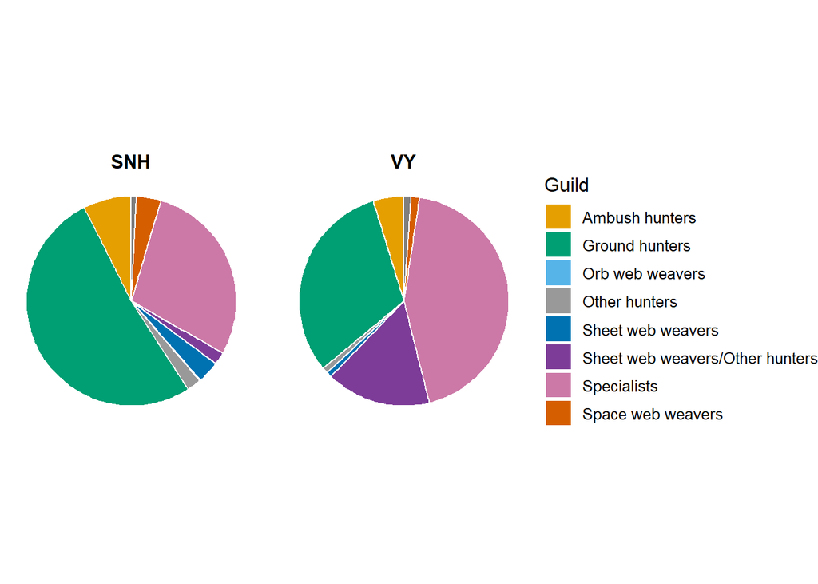

```r
# Summarize total abundance by habitat and guild, then calculate proportion
guild_prop_habitat <- guild_abundance_habitat %>%
  group_by(habitat, guild_code) %>%
  summarise(total_abundance = sum(total_abundance), .groups = "drop") %>%
  group_by(habitat) %>%
  mutate(prop = total_abundance / sum(total_abundance))

guild_prop_habitat <- guild_prop_habitat %>%
  filter(!is.na(guild_code))

# set factor order for consistent pie layout
guild_prop_habitat$guild_code <- factor(guild_prop_habitat$guild_code)


# Plot pie chart by habitat using facet
spider_traits_pie <- ggplot(guild_prop_habitat, aes(x = "", y = prop, fill = guild_code)) +
  geom_bar(stat = "identity", width = 1, color = "white") +
  coord_polar("y") +
  facet_wrap(~habitat) +
  scale_fill_manual(values = guild_colors, labels = guild_labels) +
  labs(
    fill = "Guild",
  ) +
  theme_void(base_size = 12) +
  theme(
    strip.text = element_text(size = 12, face = "bold"),
    legend.position = "right"
  )

spider_traits_pie
```

## 5 CARABIDS

### 5.1 Data import and pre-processing

This section loads the carabid raw data and prepares it for modelling.

```r
# Load data and coordinates for sites
carabid_habitat_df <- read.csv(here::here("00_data","carabid_habitat_df.csv"))

# Filter out field margins and september data from the main analysis
carabid_habitat_df <- carabid_habitat_df %>%
  filter(
    subhabitat != "FM",
    sample_period != "SEP"
  )


# Identify species columns
non_species <- c(
  "pitfall_ID","total_abundance","carabid_abundance","species_richness","destroyed",
  "site_code","site_ID","habitat","subhabitat","management_type",
  "sample_period","year","trap_number", "trap_count"
)

species_cols <- setdiff(names(carabid_habitat_df), non_species)

# drop any UNID (do not include in species count, only in total abundance)
unid_cols <- species_cols[grepl("^UNID\\b|^UNID\\.", species_cols)]
species_columns <- setdiff(species_cols, unid_cols)

# ensure species cols are integer counts
carabid_habitat_df <- carabid_habitat_df %>%
  mutate(across(all_of(species_columns), ~ as.integer(tidyr::replace_na(.x, 0L))))

# Summarize carabid abundance by site_ID, habitat, sample period and year
carabid_habitat_summary <- carabid_habitat_df %>%
  group_by(site_ID, habitat, sample_period, year) %>%
  summarise(
    across(all_of(species_columns), ~ sum(.x, na.rm = TRUE)),
    trap_count = n(),     # destroyed traps already removed earlier
    .groups = "drop"
  )

# Total number of carabids found in vineyards across all sites and years
total_carabids_habitat <- sum(carabid_habitat_df$total_abundance, na.rm = TRUE)

# Convert wide data (species columns) into long format
carabid_long_habitat <- carabid_habitat_summary %>%
  pivot_longer(cols = all_of(species_columns), names_to = "carabid_species", values_to = "count") %>%
  drop_na(count) %>%  # Remove missing values
  filter(count >= 0)  # Ensure only observed families are counted

# Get a list of all species observed at least once
observed_species_habitat <- carabid_long_habitat %>%
  filter(count > 0) %>%
  distinct(carabid_species) %>%
  arrange(carabid_species)


print(observed_species_habitat)
```

```
## # A tibble: 35 × 1
##    carabid_species
##    <chr>
##  1 Agonoleptus_conjunctus
##  2 Agonum_placidum
##  3 Amara_aenea
##  4 Amara_apricaria
##  5 Amara_carinata
##  6 Amara_cupreolata
##  7 Amara_latior
##  8 Amara_littoralis
##  9 Amara_musculis
## 10 Amara_obesa
## # ℹ 25 more rows
```

```r
# Also group at genus level
carabid_long_genus_habitat <- carabid_long_habitat %>%
  mutate(carabid_genus = str_extract(carabid_species, "^[A-Za-z]+")) %>%  # extract genus from species name
  group_by(site_ID, habitat, carabid_genus) %>%
  summarise(count = sum(count, na.rm = TRUE), .groups = "drop")

# Get a list of all genera observed at least once
observed_genus_habitat <- carabid_long_genus_habitat %>%
  filter(count > 0) %>%
  distinct(carabid_genus) %>%
  arrange(carabid_genus)


print(observed_genus_habitat)
```

```
## # A tibble: 16 × 1
##    carabid_genus
##    <chr>
##  1 Agonoleptus
##  2 Agonum
##  3 Amara
##  4 Anisodactylus
##  5 Bembidion
##  6 Calathus
##  7 Calosoma
##  8 Carabus
##  9 Dicheirotrichus
## 10 Dicheirus
## 11 Euryderus
## 12 Harpalus
## 13 Poecilus
## 14 Pterostichus
## 15 Scaphinotus
## 16 Trechus
```

```r
# calculate relative abundance of each spider family
carabid_genus_rel <- carabid_long_genus_habitat %>%
  group_by(carabid_genus) %>%
  summarise(n = sum(count, na.rm = TRUE), .groups = "drop") %>%
  mutate(rel_abund = n / sum(n)) %>%   # relative abundance within each habitat
  ungroup() %>%
  filter(n > 0)

carabid_genus_rel
```

| carabid_genus | n | rel_abund |
| --- | --- | --- |
| Agonoleptus | 12 | 0.010762332 |
| Agonum | 7 | 0.006278027 |
| Amara | 99 | 0.088789238 |
| Anisodactylus | 34 | 0.030493274 |
| Bembidion | 8 | 0.007174888 |
| Calathus | 232 | 0.208071749 |
| Calosoma | 39 | 0.034977578 |
| Carabus | 35 | 0.031390135 |
| Dicheirotrichus | 3 | 0.002690583 |
| Dicheirus | 2 | 0.001793722 |

[output cut: 6 more lines]

```r
cat("Total carabids in all habitats across all sites and years:", total_carabids_habitat, "\n")
```

```
## Total carabids in all habitats across all sites and years: 1115
```

```r
cat(
  "Total number of observed species in all habitats across all sites and years:",
  nrow(observed_species_habitat),
  "\n"
)
```

```
## Total number of observed species in all habitats across all sites and years: 35
```

```r
cat(
  "Total number of observed genera in all habitats across all sites and years:",
  nrow(observed_genus_habitat),
  "\n"
)
```

```
## Total number of observed genera in all habitats across all sites and years: 16
```

```r
cat("Number of site × habitat × year combinations:", nrow(carabid_habitat_summary), "\n")
```

```
## Number of site × habitat × year combinations: 90
```

### 5.2 Summary table

Let’s make a summary table for my appendix, looking at carabids by habitat type and year

```r
# table summarizing carabid species abundance by habitat/ year
carabid_species_table <- carabid_long_habitat %>%
  group_by(carabid_species, habitat, year) %>%
  summarise(
    total_abundance = sum(count, na.rm = TRUE),
    .groups = "drop"
  ) %>%
  unite(habitat_year, habitat, year) %>%
  pivot_wider(
    names_from  = habitat_year,
    values_from = total_abundance,
    values_fill = 0
  ) %>%
  mutate(Total = rowSums(across(where(is.numeric)))) %>%
  filter(Total > 0) %>%     # <-- keep only species with >0 counts
  arrange(desc(Total))

# Clean column names for Word (ie. remove the "_")
carabid_species_table <- carabid_species_table %>%
  mutate(
    carabid_species = gsub("_", " ", carabid_species)
  )


carabid_species_table
```

| carabid_species | SNH_2024 | SNH_2025 | VY_2024 | VY_2025 | Total |
| --- | --- | --- | --- | --- | --- |
| Harpalus affinis | 11 | 22 | 67 | 203 | 303 |
| Calathus fuscipes | 2 | 15 | 6 | 209 | 232 |
| Pterostichus melanarius | 1 | 27 | 15 | 121 | 164 |
| Harpalus opacipennis | 3 | 2 | 8 | 40 | 53 |
| Harpalus fraternus | 4 | 5 | 12 | 26 | 47 |
| Amara aenea | 1 | 3 | 11 | 24 | 39 |
| Calosoma tepidum | 0 | 1 | 12 | 26 | 39 |
| Anisodactylus binotatus | 0 | 13 | 1 | 14 | 28 |
| Harpalus herbivagus | 0 | 2 | 3 | 23 | 28 |
| Amara apricaria | 0 | 1 | 4 | 16 | 21 |

[output cut: 25 more lines]

```r
# save as table
write.csv(
  carabid_species_table,
  here::here("02_tables", "carabid_species_table.csv"),
  row.names = FALSE
)
```

### 5.3 Sample Coverage and Hill Diversity

Let’s calculate sample coverage and hill diversity by habitat using the iNEXT package to evaluate sample completeness among habitats and compare diversity patterns.

```r
# HILL DIVERSITY AND SAMPLE COVERAGE
# Summarize by habitat
carabid_by_habitat <- carabid_habitat_summary %>%
  group_by(habitat) %>%
  summarise(across(all_of(species_columns), ~ sum(.x, na.rm = TRUE)),
            .groups = "drop")

# Build iNEXT list: named abundance vectors (one per habitat)
carabid_list_habitat <- setNames(
  lapply(seq_len(nrow(carabid_by_habitat)), function(i) {
    v <- unlist(carabid_by_habitat[i, species_columns], use.names = TRUE)
    v[is.na(v)] <- 0
    v
  }),
  carabid_by_habitat$habitat
)

# Sample coverage + totals
carabid_sample_coverage <- DataInfo(carabid_list_habitat, datatype = "abundance")

carabid_sample_coverage
```

| Assemblage | n | S.obs | SC | f1 | f2 | f3 | f4 | f5 | f6 | f7 | f8 | f9 | f10 |
| --- | --- | --- | --- | --- | --- | --- | --- | --- | --- | --- | --- | --- | --- |
| SNH | 183 | 22 | 0.9674 | 6 | 3 | 1 | 2 | 1 | 0 | 0 | 0 | 1 | 0 |
| VY | 932 | 29 | 0.9946 | 5 | 2 | 3 | 1 | 0 | 1 | 3 | 2 | 0 | 0 |

```r
write.csv(
  carabid_sample_coverage,
  here::here("02_tables", "carabid_sample_coverage.csv"),
  row.names = FALSE
)

# Hill numbers
carabid_hill <- iNEXT(carabid_list_habitat, q = c(0, 1, 2), datatype = "abundance")

# table for hill numbers
carabid_hill_diversity <- carabid_hill$AsyEst

carabid_hill_diversity
```

| Assemblage | Diversity | Observed | Estimator | s.e. | LCL | UCL |
| --- | --- | --- | --- | --- | --- | --- |
| SNH | Species richness | 22.000000 | 27.967213 | 8.0384184 | 22.000000 | 43.722224 |
| SNH | Shannon diversity | 13.229521 | 14.343050 | 0.9429548 | 12.494892 | 16.191207 |
| SNH | Simpson diversity | 10.294805 | 10.848860 | 0.8584296 | 9.166369 | 12.531351 |
| VY | Species richness | 29.000000 | 35.243294 | 8.7443636 | 29.000000 | 52.381932 |
| VY | Shannon diversity | 9.479575 | 9.665795 | 0.3702294 | 8.940159 | 10.391432 |
| VY | Simpson diversity | 5.947606 | 5.979382 | 0.2323950 | 5.523896 | 6.434868 |

```r
# save as csv
write.csv(
  carabid_hill_diversity,
  here::here("02_tables", "carabid_hill_diversity.csv"),
  row.names = FALSE
)
```

Based on the output for hill diversity, higher observed and estimated species richness in VY, more uncertainty in SNH richness. Shannon/ simpson diversity higher in SNH but also higher uncertainty. Indicate SNH has a more even community, while VY are dominated by a few species

Let’s make some plots to visualize diversity by both sample size and sample completeness

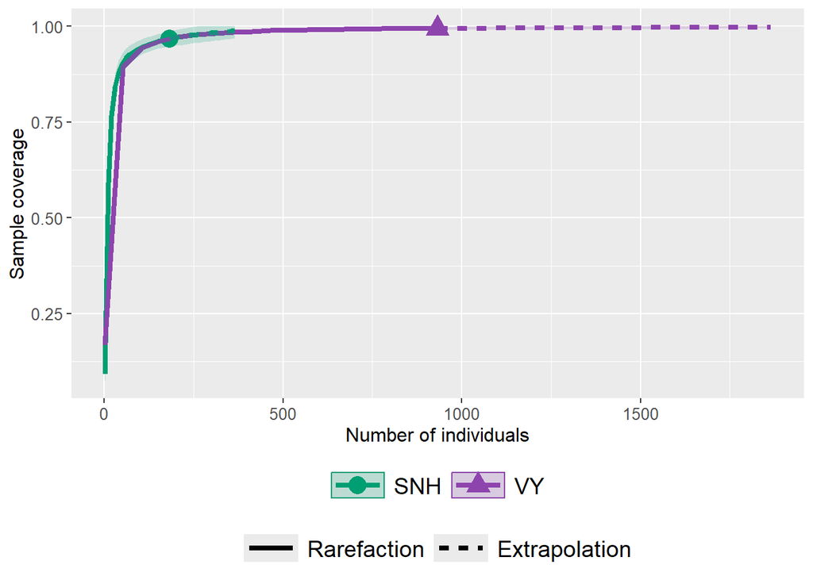

```r
# Coverage-based curves
carabid_sample_coverage <- ggiNEXT(carabid_hill, type = 2) +
  scale_colour_manual(values = custom_colors) +
  scale_fill_manual(values = custom_colors) +
  theme(
    legend.title = element_blank(),
    axis.title  = element_text(size = 12),
    axis.text   = element_text(size = 10)
  )

carabid_sample_coverage
```

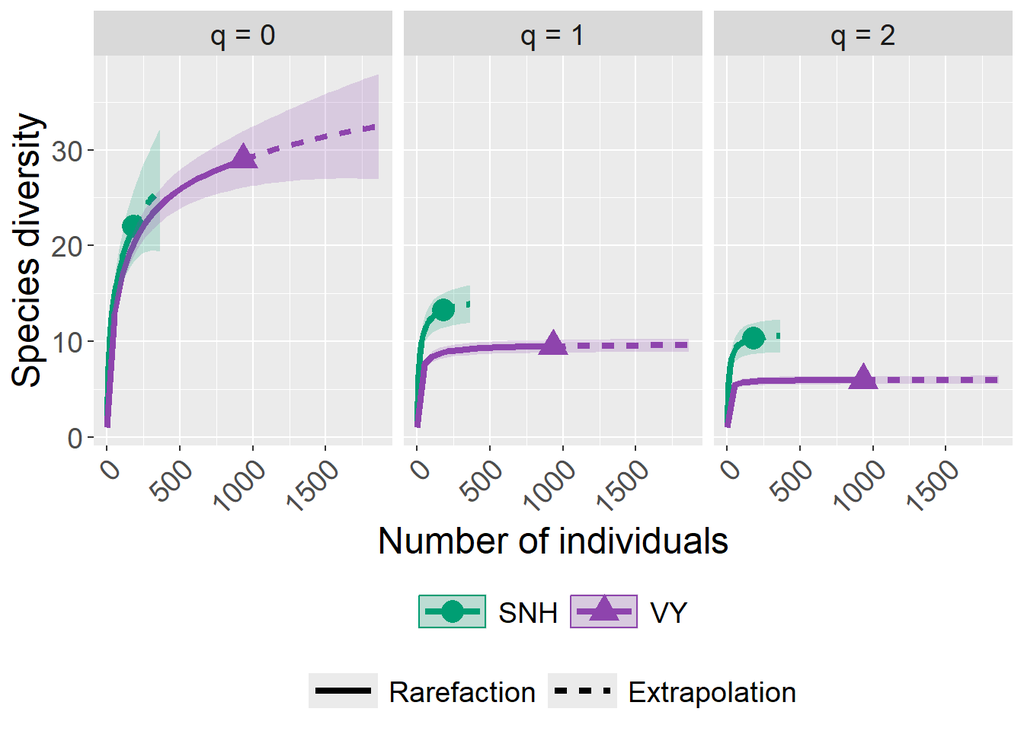

```r
# Coverage-based Hill curves
carabid_hill_size <- ggiNEXT(carabid_hill, type = 1,
  facet.var="Order.q") +
  scale_colour_manual(values = custom_colors) +
  scale_fill_manual(values = custom_colors) +
  theme(
    axis.text.x = element_text(angle = 45, hjust = 1)
  )

carabid_hill_size
```

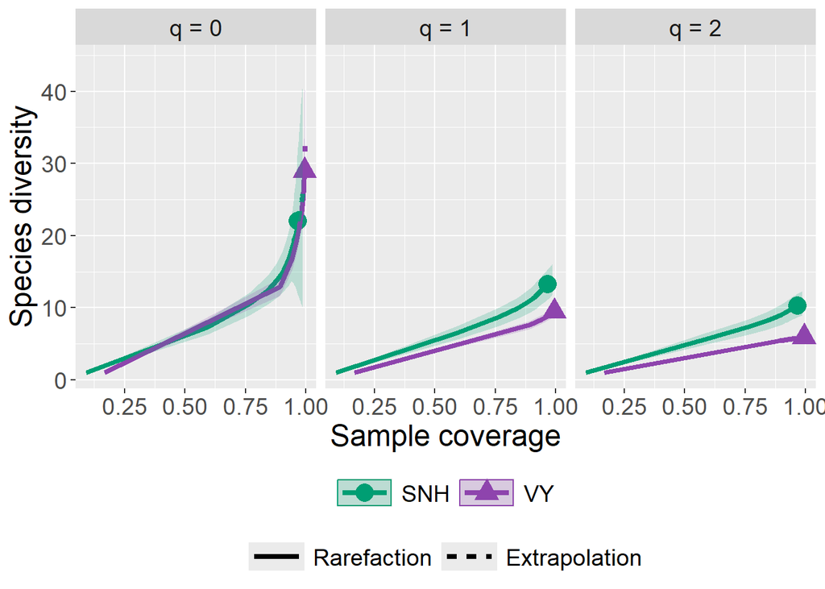

```r
# Coverage-based Hill curves
carabid_hill_coverage <- ggiNEXT(
  carabid_hill,
  type = 3,
  facet.var = "Order.q"
) +
  scale_colour_manual(values = custom_colors) +
  scale_fill_manual(values = custom_colors)

carabid_hill_coverage
```

### 5.4 Data Exploration

#### 5.4.1 Relative abundance plots

Let’s visualize the carabid relative abundance (at the genus level since it’s easier to read x axis)

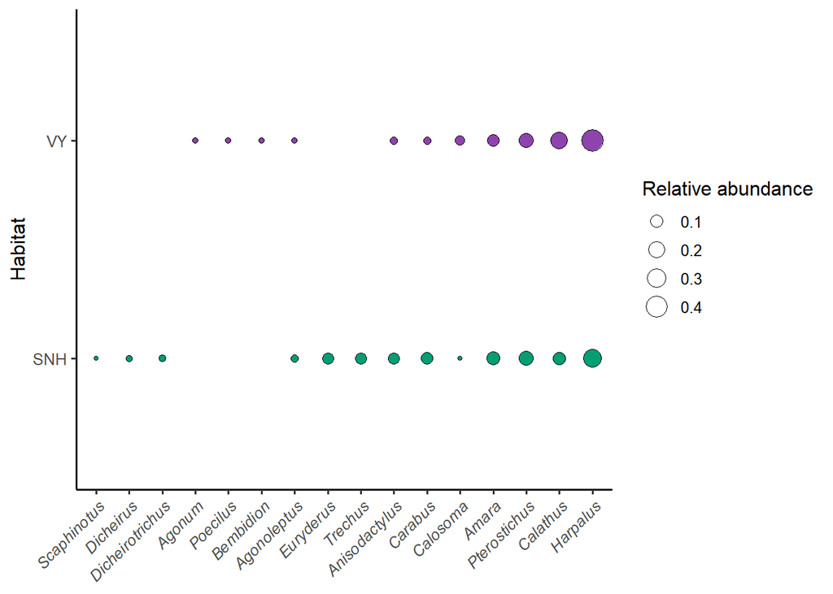

```r
custom_colors <- c("VY"="#8E44AD","SNH"="#009E73")

# 1) Summarise total individuals per habitat x genus
carabid_species_habitat_rel <- carabid_long_genus_habitat %>%
  group_by(habitat, carabid_genus) %>%
  summarise(n = sum(count, na.rm = TRUE), .groups = "drop") %>%
  group_by(habitat) %>%
  mutate(rel_abund = n / sum(n)) %>%   # relative abundance within each habitat
  ungroup() %>%
  filter(n > 0)

# 2) Order species (overall abundance across all habitats)
species_order <- carabid_species_habitat_rel %>%
  group_by(carabid_genus) %>%
  summarise(total_n = sum(n), .groups = "drop") %>%
  arrange(total_n) %>%
  pull(carabid_genus)

carabid_species_habitat_rel <- carabid_species_habitat_rel %>%
  mutate(carabid_genus = factor(carabid_genus, levels = species_order))

# 3) Bubble plot of relative abundance of each family by habitat type
carabid_genus_relative_abundance <- ggplot(carabid_species_habitat_rel,
       aes(x = carabid_genus, y = habitat,
           size = rel_abund, fill = habitat)) +
  geom_point(shape = 21, color = "black", alpha = 1) +
  scale_size_continuous(name = "Relative abundance") +
  scale_fill_manual(values = custom_colors) +
  labs(x = NULL, y = "Habitat") +
  theme_classic(base_size = 12) +
  theme(
    axis.text.x = element_text(angle = 45, hjust = 1,  face = "italic"),
    legend.position = "right"
  ) +
  guides(fill = "none")


carabid_genus_relative_abundance
```

```r
# define custom colors
custom_colors <- c("VY"="#8E44AD","SNH"="#009E73")

# -----------------------------
# HABITAT ABUNDANCE, SPECIES RICHNESS, MEAN PER TRAP AND RAREFIED RICHNESS
# -----------------------------
# ALL HABITATS RICHNESS
sp_mat            <- as.matrix(dplyr::select(carabid_habitat_summary, all_of(species_columns)))
total_abundance   <- rowSums(sp_mat)
species_richness  <- rowSums(sp_mat > 0)

#   Use the minimum total individuals among groups with > min_m_individuals
min_m_individuals <- 20L
m_candidates      <- total_abundance[total_abundance > min_m_individuals]

rarefaction_m <- if (length(m_candidates)) min(m_candidates) else NA_integer_

# Rarefy (individual-based); NA if m not available
rarefied_richness <- if (is.na(rarefaction_m)) {
  rep(NA_real_, nrow(sp_mat))
} else {
  vegan::rarefy(sp_mat, sample = rarefaction_m)
}

# Assemble final summary table
carabid_habitat_data <- carabid_habitat_summary %>%
  dplyr::select(site_ID, habitat, sample_period, year, trap_count) %>%
  mutate(
    total_abundance   = total_abundance,
    mean_per_trap     = ifelse(trap_count > 0, total_abundance / trap_count, NA_real_),
    species_richness  = species_richness,
    rarefied_richness = rarefied_richness,
    rarefaction_m     = rarefaction_m
  ) %>%
  arrange(site_ID, year, sample_period, habitat)

# calculate mean per trap by habitat
carabid_mean_by_habitat <- carabid_habitat_data %>%
  dplyr::group_by(habitat) %>%
  dplyr::summarise(
    mean_per_trap = mean(mean_per_trap, na.rm = TRUE),
    n             = dplyr::n(),
    .groups = "drop"
  )
carabid_mean_by_habitat
```

| habitat | mean_per_trap | n |
| --- | --- | --- |
| SNH | 0.7596296 | 45 |
| VY | 3.5348148 | 45 |

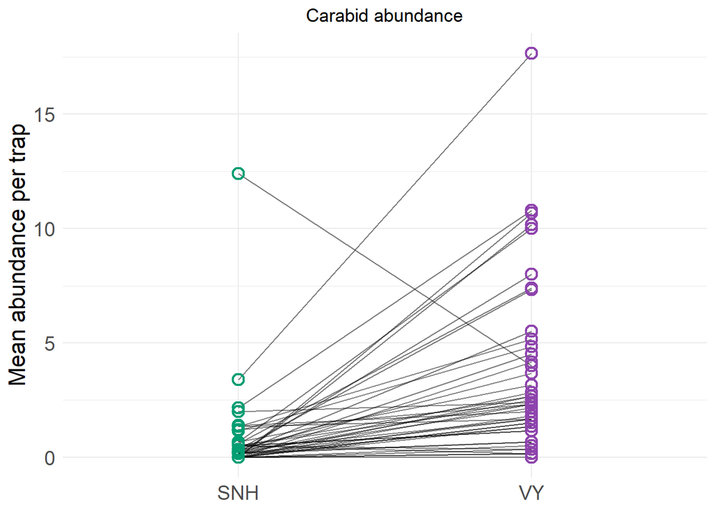

```r
# plot mean abundance per trap by Habitat (VY/ SNH)
# lets use line plots to account for paired design (each site has a VY and SNH)
# we're using mean per plot instead of total abundance to account for traps lost in the field
carabid_abundance_line <- ggplot(
  carabid_habitat_data,
  aes(
    x = habitat,
    y = mean_per_trap,
    group = interaction(site_ID, year)
  )
) +
  # paired lines in grey
  geom_line(
    color = "black",
    alpha = 0.5
  ) +
  # points coloured by habitat
  geom_point(
    aes(color = habitat),
    shape = 21,
    size = 3,
    stroke = 1.2
  ) +
  scale_color_manual(values = custom_colors) +
  scale_fill_manual(values = custom_colors) +
  labs(
    title = "Carabid abundance",
    x = NULL,
    y = "Mean abundance per trap"
  ) +
  theme_minimal() +
  theme(
    plot.title = element_text(hjust = 0.5),
    legend.position = "none"
  ) + theme(
  axis.text.x  = element_text(size = 14),
  axis.text.y  = element_text(size = 14),
  axis.title.y = element_text(size = 16)
)


carabid_abundance_line
```

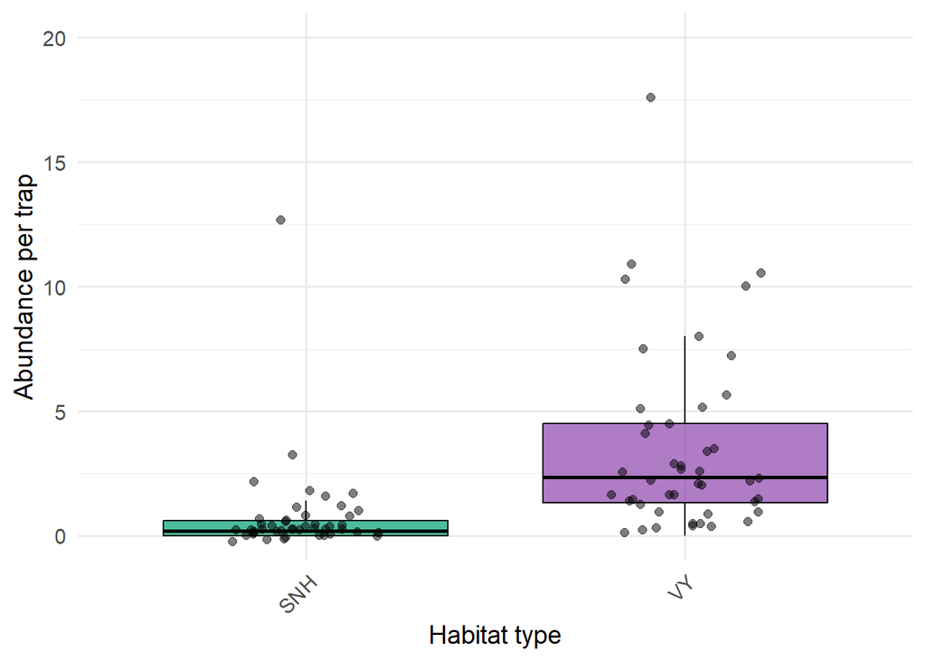

```r
# let's also try with boxplots
carabid_mean_abundance <- ggplot(carabid_habitat_data, aes(x = habitat, y = mean_per_trap, fill = habitat)) +
  geom_boxplot(outlier.shape = NA, alpha = 0.7, color = "black") +
  geom_jitter(width = 0.2, height = 0.3, alpha = 0.5, size = 2, color = "black")+
  coord_cartesian(ylim = c(0, 20)) +
  labs(
    x = "Habitat type",
    y = "Abundance per trap"
  ) +
  theme_minimal(base_size = 14) +
  scale_fill_manual(values = custom_colors) +
  theme(
    legend.position = "none",
    plot.title = element_text(face = "bold", hjust = 0.5),
    axis.text.x = element_text(angle = 45, hjust = 1)
  )
carabid_mean_abundance
```

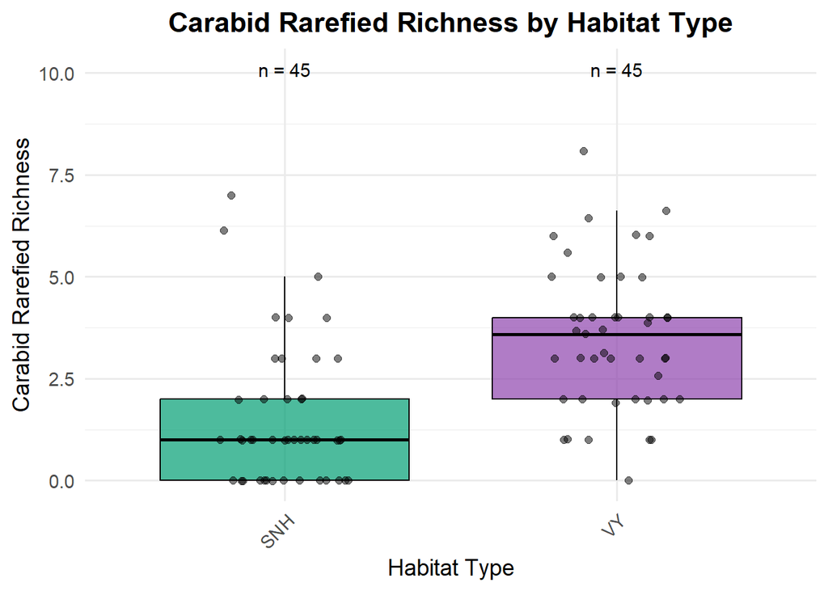

```r
# rarefied richness
carabid_rarefied_richness <- ggplot(carabid_habitat_data, aes(x = habitat, y = rarefied_richness, fill = habitat)) +
  geom_boxplot(outlier.shape = NA, alpha = 0.7, color = "black") +
  geom_jitter(width = 0.2, alpha = 0.5, size = 2, color = "black") +
  geom_text(
    data = habitat_n,
    aes(
      x = habitat,
      y = max(carabid_habitat_data$rarefied_richness, na.rm = TRUE) + 2,
      label = paste0("n = ", n)
    ),
    inherit.aes = FALSE,
    size = 4
  ) +
  labs(
    title = "Carabid Rarefied Richness by Habitat Type",
    x = "Habitat Type",
    y = "Carabid Rarefied Richness"
  ) +
  theme_minimal(base_size = 14) +
  scale_fill_manual(values = custom_colors) +
  theme(
    legend.position = "none",
    plot.title = element_text(face = "bold", hjust = 0.5),
    axis.text.x = element_text(angle = 45, hjust = 1))

carabid_rarefied_richness
```

Generally, much higher abundance in VY compared to SNH.

#### 5.4.2 Venn diagrams by habitat

```r
# plot as venn diagram
# Presence-absence by habitat
carabid_presence <- carabid_habitat_summary %>%
  dplyr::select(-site_ID, -sample_period, -year, -trap_count) %>%
  group_by(habitat) %>%
  summarise(across(where(is.numeric), ~ sum(.x > 0) > 0))

# Create lists of carabid families present in each habitat
carabid_species_by_habitat <- lapply(split(carabid_presence, carabid_presence$habitat), function(df) {
  names(df)[which(as.logical(df[-1])) + 1]  # Skip habitat column
})
carabid_species_by_habitat
```

```
## $SNH
##  [1] "Agonoleptus_conjunctus"   "Amara_aenea"              "Amara_apricaria"          "Amara_obesa"              "Amara_quenseli"           "Amara_rectangula"         "Amara_spp"                "Anisodactylus_binotatus"  "Calathus_fuscipes"        "Calosoma_tepidum"         "Carabus_nemoralis"   …
##
## $VY
##  [1] "Agonoleptus_conjunctus"  "Agonum_placidum"         "Amara_aenea"             "Amara_apricaria"         "Amara_carinata"          "Amara_cupreolata"        "Amara_latior"            "Amara_littoralis"        "Amara_musculis"          "Amara_obesa"             "Amara_quenseli"          "Amara…
```

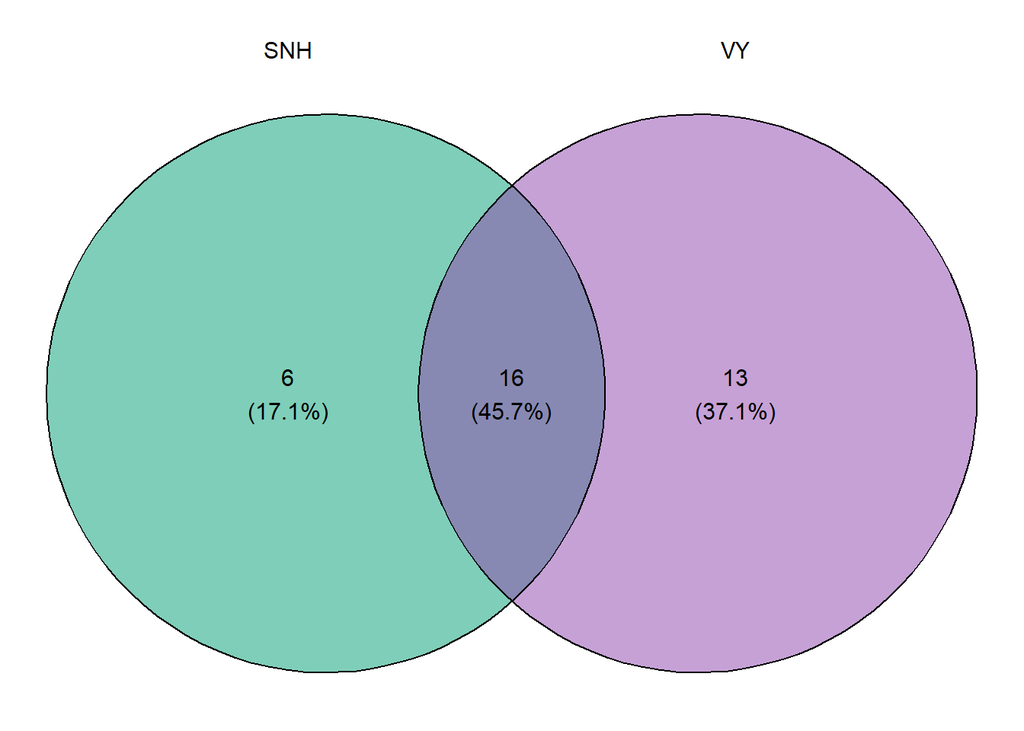

```r
# plot as a venn diagram
ggvenn_carabid_species <- ggvenn(carabid_species_by_habitat,
                        fill_color = c("#009E73", "#8E44AD"),
                        stroke_size = 0.5,
                        set_name_size = 4,
                        text_size = 4)
ggvenn_carabid_species
```

```r
# GENUS LEVEL
# Step 1: Summarize genus presence by habitat
carabid_genus_presence <- carabid_long_genus_habitat %>%
  group_by(habitat, carabid_genus) %>%
  summarise(present = any(count > 0), .groups = "drop") %>%
  pivot_wider(names_from = carabid_genus, values_from = present, values_fill = FALSE)

# Step 2: Create lists of genera present in each habitat
carabid_genus_by_habitat <- lapply(split(carabid_genus_presence, carabid_genus_presence$habitat), function(df) {
  names(df)[which(as.logical(df[-1])) + 1]  # skip habitat column
})

carabid_genus_by_habitat
```

```
## $SNH
##  [1] "Agonoleptus"     "Amara"           "Anisodactylus"   "Calathus"        "Calosoma"        "Carabus"         "Dicheirotrichus" "Dicheirus"       "Euryderus"       "Harpalus"        "Pterostichus"    "Scaphinotus"     "Trechus"
##
## $VY
##  [1] "Agonoleptus"   "Agonum"        "Amara"         "Anisodactylus" "Bembidion"     "Calathus"      "Calosoma"      "Carabus"       "Harpalus"      "Poecilus"      "Pterostichus"
```

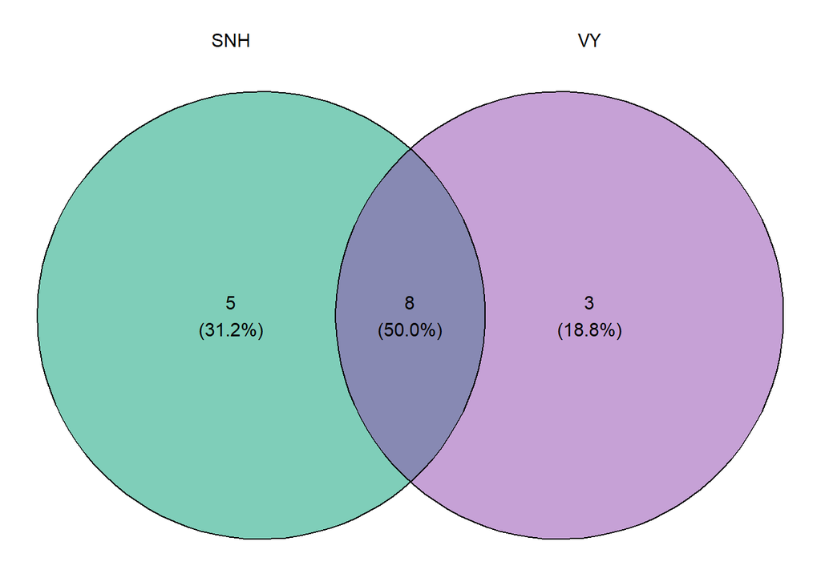

```r
# Step 3: Plot Venn diagram
# add a margin to prevent the labels from getting cut off when combined
ggvenn_carabid_genus <- ggvenn(
  carabid_genus_by_habitat,
  fill_color = c("#009E73", "#8E44AD"),
  stroke_size = 0.5,
  set_name_size = 4,
  text_size = 4)

ggvenn_carabid_genus
```

```r
print(carabid_genus_by_habitat)
```

```
## $SNH
##  [1] "Agonoleptus"     "Amara"           "Anisodactylus"   "Calathus"        "Calosoma"        "Carabus"         "Dicheirotrichus" "Dicheirus"       "Euryderus"       "Harpalus"        "Pterostichus"    "Scaphinotus"     "Trechus"
##
## $VY
##  [1] "Agonoleptus"   "Agonum"        "Amara"         "Anisodactylus" "Bembidion"     "Calathus"      "Calosoma"      "Carabus"       "Harpalus"      "Poecilus"      "Pterostichus"
```

#### 5.4.3 Carabid Traits by Habitat

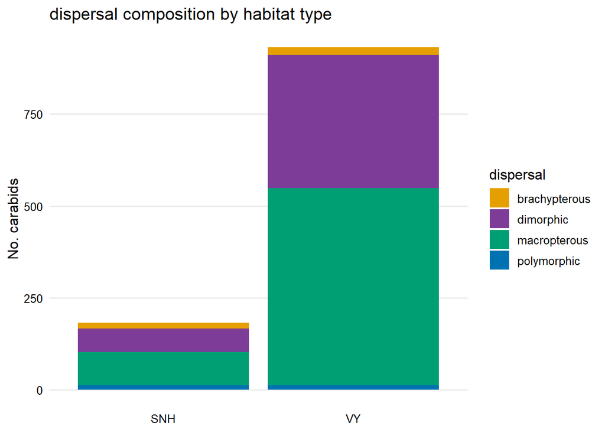

```r
# upload the traits data (dispersal and status)
carabid_traits <- read.csv(here::here ("00_data", "carabid_traits.csv"))


# join to carabid habitat data (in long format)
carabid_long_traits_habitat <- carabid_long_habitat %>%
  dplyr::left_join(
    dplyr::select(carabid_traits, carabid_species, dispersal_power, status),
    by = "carabid_species"
  )


# summarize dispersal abundance by site_ID, habitat and year
dispersal_abundance_habitat <- carabid_long_traits_habitat %>%
  group_by(site_ID, habitat, year, dispersal_power) %>%
  summarise(total_abundance = sum(count), .groups = "drop")

# summarize dispersal abundance by site_ID, habitat and year
status_abundance_habitat <- carabid_long_traits_habitat %>%
  group_by(site_ID, habitat, year, status) %>%
  summarise(total_abundance = sum(count), .groups = "drop")

# pivot to wide format
dispersal_abundance_wide <- dispersal_abundance_habitat %>%
  pivot_wider(
    names_from = dispersal_power,
    values_from = total_abundance,
    values_fill = 0  # fill missing combinations with 0
  )

# Make sure dispersal_abundance_habitat is prepared
status_abundance_plot <- status_abundance_habitat %>%
  group_by(habitat, status) %>%
  summarise(total_abundance = sum(total_abundance), .groups = "drop")
status_abundance_plot <- status_abundance_plot %>%
  filter(!is.na(status))

# Make sure dispersal_abundance_habitat is prepared
dispersal_abundance_plot <- dispersal_abundance_habitat %>%
  group_by(habitat, dispersal_power) %>%
  summarise(total_abundance = sum(total_abundance), .groups = "drop")
dispersal_abundance_plot <- dispersal_abundance_plot %>%
  filter(!is.na(dispersal_power))

status_colors <- c(
  "introduced" = "#E69F00",     # orange
  "native" = "#009E73"     # bluish green
)

# Custom colors (edit to match your desired palette)
dispersal_colors <- c(
  "brachypterous" = "#E69F00",     # orange
  "macropterous" = "#009E73",     # bluish green
  "polymorphic" = "#0072B2",     # sky blue
  "dimorphic" = "#7D3C98"     # blue
)

# Create the stacked bar chart for both dispersal and status
ggplot(dispersal_abundance_plot, aes(x = habitat, y = total_abundance, fill = dispersal_power)) +
  geom_bar(stat = "identity") +
  scale_fill_manual(values = dispersal_colors) +
  labs(
    x = NULL,
    y = "No. carabids",
    fill = "dispersal",
    title = "dispersal composition by habitat type"
  ) +
  theme_minimal(base_size = 12) +
  theme(
    axis.text = element_text(color = "black"),
    panel.grid.major.x = element_blank(),
    panel.grid.minor = element_blank()
  )
```

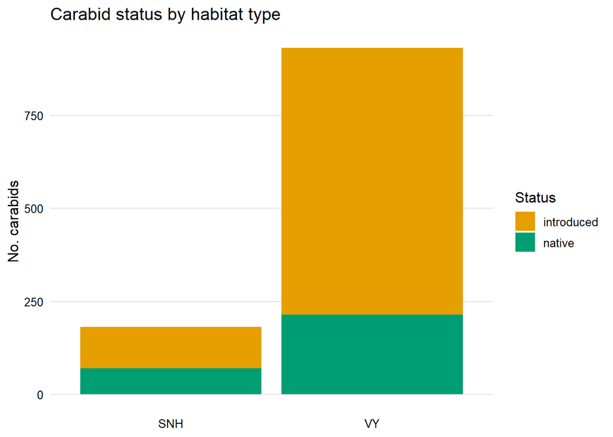

```r
# Create the stacked bar chart
ggplot(status_abundance_plot, aes(x = habitat, y = total_abundance, fill = status)) +
  geom_bar(stat = "identity") +
  scale_fill_manual(values = status_colors) +
  labs(
    x = NULL,
    y = "No. carabids",
    fill = "Status",
    title = "Carabid status by habitat type"
  ) +
  theme_minimal(base_size = 12) +
  theme(
    axis.text = element_text(color = "black"),
    panel.grid.major.x = element_blank(),
    panel.grid.minor = element_blank()
  )
```

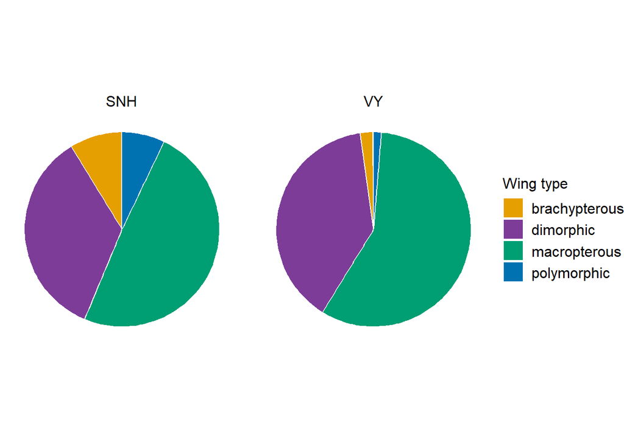

```r
# Summarize total abundance by habitat and dispersal, then calculate proportion
dispersal_prop_habitat <- dispersal_abundance_habitat %>%
  group_by(habitat, dispersal_power) %>%
  summarise(total_abundance = sum(total_abundance), .groups = "drop") %>%
  group_by(habitat) %>%
  mutate(prop = total_abundance / sum(total_abundance))

dispersal_prop_habitat <- dispersal_prop_habitat %>%
  filter(!is.na(dispersal_power))

# Summarize total abundance by habitat and dispersal, then calculate proportion
status_prop_habitat <- status_abundance_habitat %>%
  group_by(habitat, status) %>%
  summarise(total_abundance = sum(total_abundance), .groups = "drop") %>%
  group_by(habitat) %>%
  mutate(prop = total_abundance / sum(total_abundance))


# set factor order for consistent pie layout
dispersal_prop_habitat$dispersal_power <- factor(dispersal_prop_habitat$dispersal_power)


# Plot pie chart by habitat using facet
carabid_dispersal_pie <- ggplot(dispersal_prop_habitat, aes(x = "", y = prop, fill = dispersal_power)) +
  geom_bar(stat = "identity", width = 1, color = "white") +
  coord_polar("y") +
  facet_wrap(~habitat) +
  scale_fill_manual(values = dispersal_colors) +
  labs(
    fill = "Wing type",
  ) +
  theme_void(base_size = 12) +
  theme(
    strip.text = element_text(size = 12),
    legend.position = "right",
    legend.text = element_text(size = 12)
  )

carabid_dispersal_pie
```

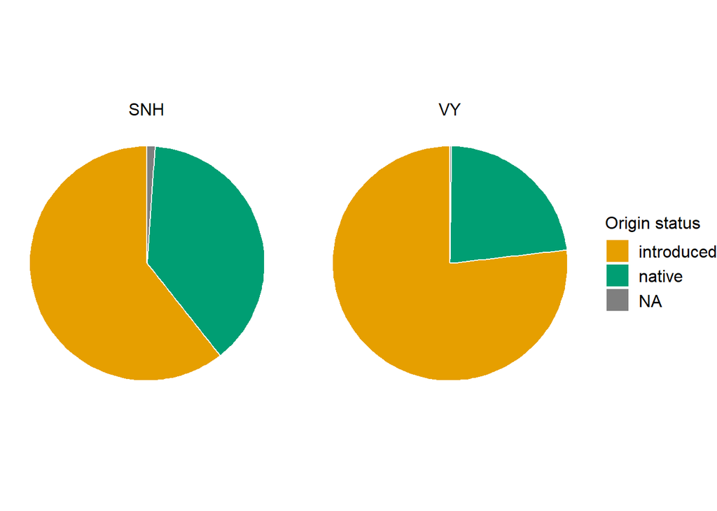

```r
# Plot pie chart by habitat using facet
carabid_status_pie <- ggplot(status_prop_habitat, aes(x = "", y = prop, fill = status)) +
  geom_bar(stat = "identity", width = 1, color = "white") +
  coord_polar("y") +
  facet_wrap(~habitat) +
  scale_fill_manual(values = status_colors) +
  labs(
    fill = "Origin status",
  ) +
  theme_void(base_size = 12) +
  theme(
    strip.text = element_text(size = 12),
    legend.position = "right",
    legend.text = element_text(size = 12)
  )

carabid_status_pie
```

Higher proportion of native species in SNH compared to VY, and higher proportion of brachypterous and polymorphic wing types in SNH. But also much lower abundance overall in SNH, so actually similar number of individuals in each habitat.

## 6 FIGURES

Let’s combine some figures from all of the response and predictor variables to include in my thesis/ papers.

### 6.1 Sample coverage and hill diversity

One of sample coverage for the appendix

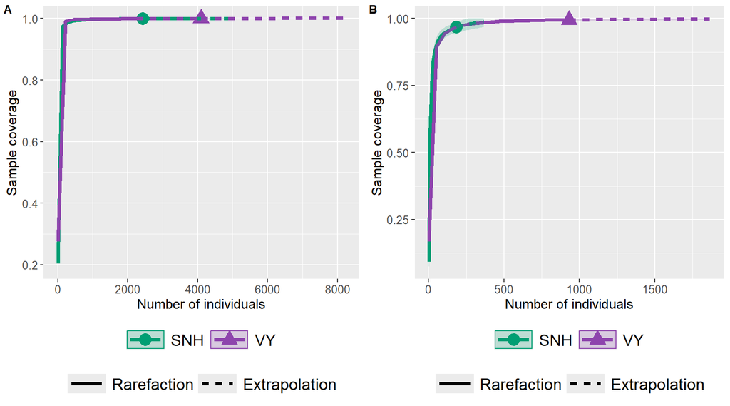

```r
# combine sample coverage/ hill diversity plots
combined_sample_coverage <- cowplot::plot_grid(
  spider_sample_coverage,
  carabid_sample_coverage,
  labels = c("A", "B"),
  label_size = 10,
  ncol = 2,
  rel_heights = c(1, 1)
)
combined_sample_coverage
```

```r
# save to figures folder
ggsave(
   filename = here::here("03_figures","combined_sample_coverage.png"),
  combined_sample_coverage,
  width = 8,
  height = 4,
  dpi = 400
)
```

combined hill diversity by sample coverage plot

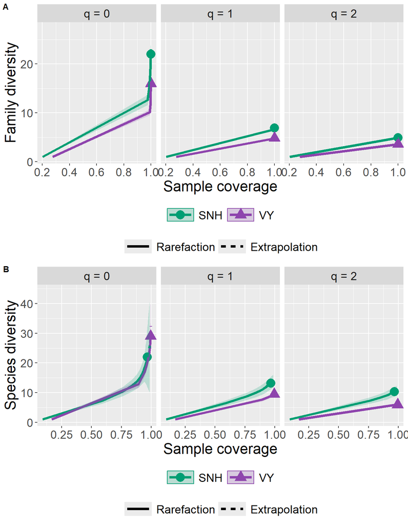

```r
# combine sample coverage/ hill diversity plots
combined_hill_coverage <- cowplot::plot_grid(
  spider_hill_coverage,
  carabid_hill_coverage,
  labels = c("A", "B"),
  label_size = 10,
  ncol = 1,
  rel_heights = c(1, 1)
)
combined_hill_coverage
```

```r
# save to figures folder
ggsave(
   filename = here::here("03_figures","combined_hill_coverage.png"),
  combined_hill_coverage,
  width = 7,
  height = 8,
  dpi = 400
)
```

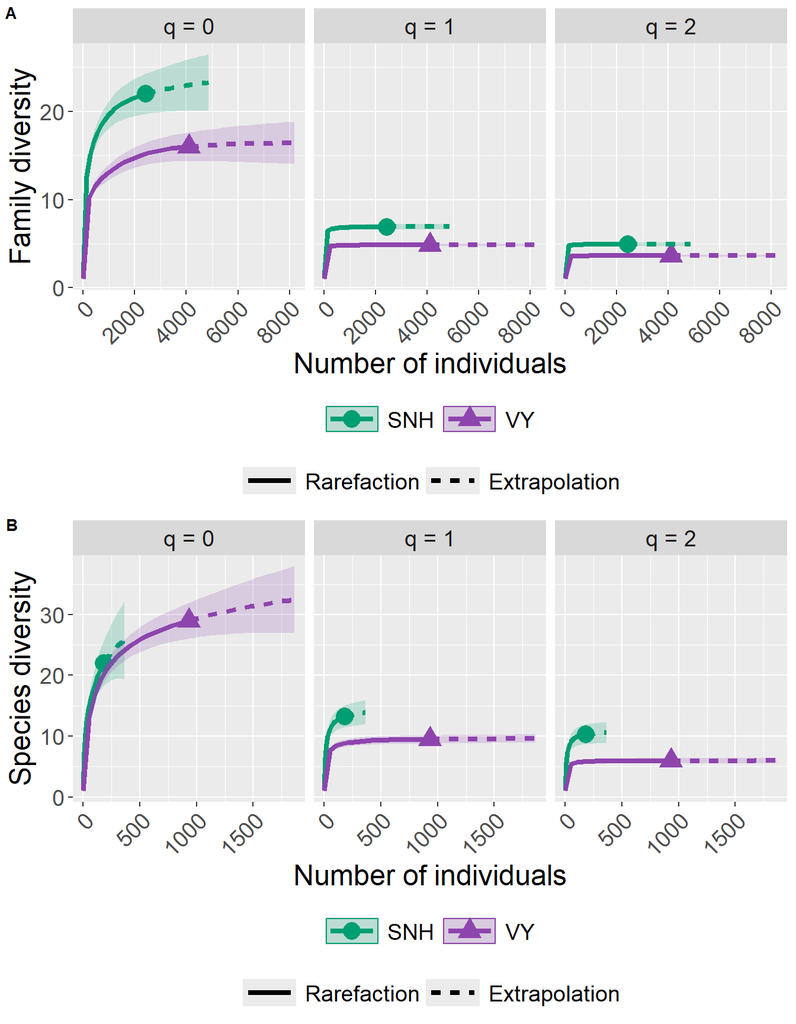

```r
# combine hill diversity plots by sample size
combined_hill_size <- cowplot::plot_grid(
  spider_hill_size,
  carabid_hill_size,
  labels = c("A", "B"),
  label_size = 10,
  ncol = 1,
  rel_heights = c(1, 1)
)
combined_hill_size
```

```r
# save to figures folder
ggsave(
   filename = here::here("03_figures","combined_hill_size.png"),
  combined_hill_size,
  width = 7,
  height = 8,
  dpi = 400
)
```

### 6.2 Boxplots of abundance by habitat type

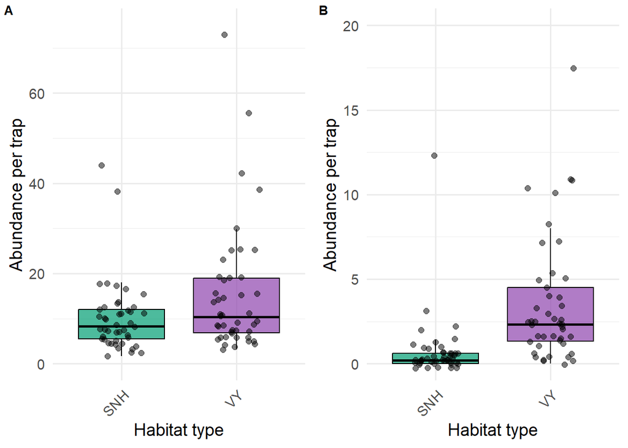

```r
# combine mean abundance plots
combined_mean_abundance <- cowplot::plot_grid(
  spider_mean_abundance,
  carabid_mean_abundance,
  labels = c("A", "B"),
  label_size = 10,
  ncol = 2,
  rel_heights = c(1, 1)
)
combined_mean_abundance
```

```r
# save to figures folder
ggsave(
   filename = here::here("03_figures","mean_abundance_boxplot.png"),
  combined_mean_abundance,
  width = 8,
  height = 5,
  dpi = 400
)
```

### 6.3 Line plots by habitat type

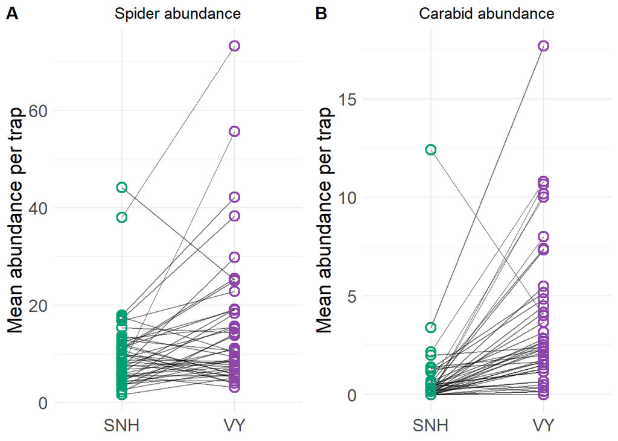

```r
# combine mean abundnce plots
combined_abundance_line <- cowplot::plot_grid(
  spider_abundance_line,
  carabid_abundance_line,
  labels = c("A", "B"),
  label_size = 14,
  ncol = 2,
  rel_heights = c(1, 1)
)
combined_abundance_line
```

```r
# save to figures folder
ggsave(
   filename = here::here("03_figures","mean_abundance_lineplot.png"),
  combined_abundance_line,
  width = 8,
  height = 4,
  dpi = 400
)
```

### 6.4 Venn Diagrams

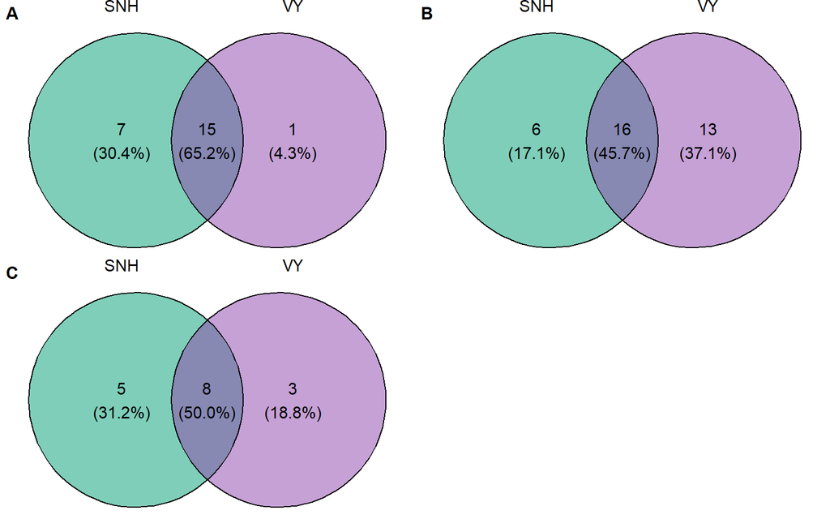

```r
# combine venn diagram plots
combined_venn <- cowplot::plot_grid(
  ggvenn_spider_families,
  ggvenn_carabid_species,
  ggvenn_carabid_genus,
  labels = c("A", "B", "C"),
  label_size = 12,
  ncol = 2,
  rel_heights = c(1,1)
)
combined_venn
```

```r
# save to figures folder
ggsave(
   filename = here::here("03_figures","ven_diagram.png"),
  combined_venn,
  width = 8,
  height = 6,
  dpi = 400
)
```

### 6.5 Trait figures

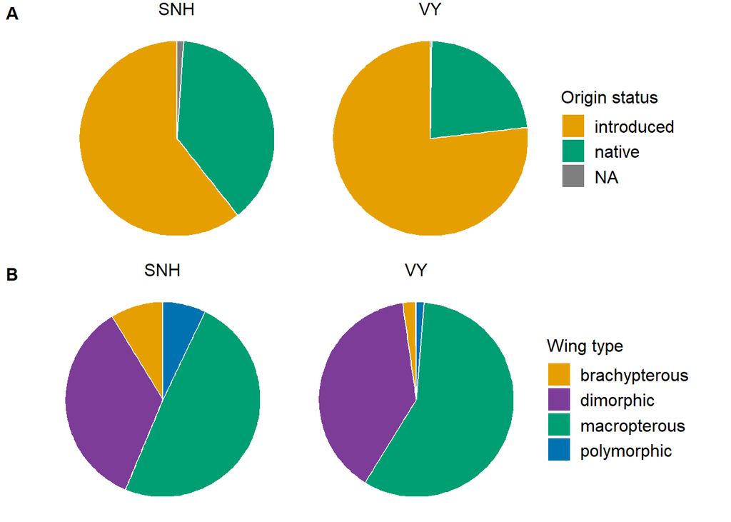

```r
# combine relative abundnce plots
combined_trait_carabid <- cowplot::plot_grid(
  carabid_status_pie,
  carabid_dispersal_pie,
  labels = c("A", "B", "C"),
  label_size = 12,
  ncol = 1,
  rel_heights = c(1, 1)
)
combined_trait_carabid
```

```r
# save to figures folder
ggsave(
   filename = here::here("03_figures","carabid_traits_pie.png"),
  combined_trait_carabid,
  width = 8,
  height = 6,
  dpi = 400
)
```

## 7 GLLVM’s

### 7.1 Spider GLLVM

This section uses generalized linear latent variable models (GLLVM)

```r
# Pivot to long format to count presence
family_presence <- spider_habitat_summary %>%
  dplyr::select(all_of(family_columns)) %>%
  pivot_longer(cols = everything(), names_to = "family", values_to = "count") %>%
  group_by(family) %>%
  summarise(n_samples = sum(count > 0), .groups = "drop")

# Filter families with at least 5 non-zero entries
families_to_keep <- family_presence %>%
  filter(n_samples >= 5) %>%
  pull(family)
print(families_to_keep)
```

```
##  [1] "AGELENIDAE"     "CORINNIDAE"     "DICTYNIDAE"     "GNAPHOSIDAE"    "LINYPHIIDAE"    "LYCOSIDAE"      "PHILODROMIDAE"  "PHOLCIDAE"      "PHRUROLITHIDAE" "SALTICIDAE"     "THERIDIIDAE"    "THOMISIDAE"     "TITANOECIDAE"   "ZODARIIDAE"
```

```r
observed_families <- observed_families_habitat %>% dplyr::pull(spider_family)

# Response matrix (all family counts)
Y_spider <- spider_habitat_summary %>%
  dplyr::select(all_of(observed_families)) %>%
  as.matrix()

# Filter Y to include only common species
Y_spider_rare_removed <- spider_habitat_summary %>%
  dplyr::select(all_of(families_to_keep)) %>%
  as.matrix()

# Offset (log effort) and final response matrix
effort_vec <- pmax(spider_habitat_summary$trap_count, 1L)
off_vec    <- log(effort_vec)


site_ID <- spider_habitat_summary %>%
  dplyr::pull(site_ID) %>%
  factor()

studyDesign <- data.frame(site_ID = factor(site_ID))


# Covariate C matrix (habitat and season only)
X_spider <- spider_habitat_summary %>%
  dplyr::select(habitat, year) %>%
  mutate(across(everything(), as.factor))
```

```r
# Fit GLLVM using factors habitat and year
# rare families (<5) removed
gllvm_spider_pois <- gllvm(
  y = Y_spider_rare_removed,
  X = X_spider,
  family = "poisson",
  formula = ~ habitat + year,
  num.lv = 2,
  studyDesign = studyDesign,
  row.eff = ~(1 | site_ID),
  offset = off_vec,
  method = "VA"
)

summary(gllvm_spider_pois)
```

```
##
## Call:
## gllvm(y = Y_spider_rare_removed, X = X_spider, formula = ~habitat +
##     year, family = "poisson", num.lv = 2, studyDesign = studyDesign,
##     row.eff = ~(1 | site_ID), offset = off_vec, method = "VA")
##
## Family:  poisson
##
## AIC:  5238.492 AICc:  5246.852 BIC:  5598.212 LL:  -2549.2 df:  70
##
## Informed LVs:  0
## Constrained LVs:  0
## Unconstrained LVs:  2
##
## Formula:  ~habitat + year
## LV formula:  ~1
## Row effect:  ~(1 | site_ID)
##
## Coefficients predictors:
##                          Estimate Std. Error z value Pr(>|z|)
## habitatVY:AGELENIDAE     -0.71410    0.21435  -3.331 0.000864 ***
## habitatVY:CORINNIDAE     -1.68368    0.63796  -2.639 0.008311 **
## habitatVY:DICTYNIDAE      1.27700    0.39303   3.249 0.001158 **
## habitatVY:GNAPHOSIDAE     0.32568    0.11057   2.946 0.003223 **
## habitatVY:LINYPHIIDAE     2.78916    0.28281   9.862  < 2e-16 ***
## habitatVY:LYCOSIDAE       0.23481    0.14375   1.634 0.102356
## habitatVY:PHILODROMIDAE   0.42553    0.73912   0.576 0.564802
## habitatVY:PHOLCIDAE      -0.29230    0.77797  -0.376 0.707126
## habitatVY:PHRUROLITHIDAE -2.11688    0.39126  -5.410 6.29e-08 ***
## habitatVY:SALTICIDAE     -0.46308    0.25125  -1.843 0.065314 .
## habitatVY:THERIDIIDAE    -0.49488    0.19909  -2.486 0.012927 *
## habitatVY:THOMISIDAE     -0.03247    0.13866  -0.234 0.814859
## habitatVY:TITANOECIDAE   -1.47997    0.65098  -2.273 0.022999 *
## habitatVY:ZODARIIDAE      0.68665    0.55870   1.229 0.219068
## year2025:AGELENIDAE       1.06568    0.29007   3.674 0.000239 ***
## year2025:CORINNIDAE      -1.26507    0.47885  -2.642 0.008244 **
## year2025:DICTYNIDAE       1.32396    0.46651   2.838 0.004540 **
## year2025:GNAPHOSIDAE     -0.08445    0.11851  -0.713 0.476123
## year2025:LINYPHIIDAE      0.69895    0.27472   2.544 0.010953 *
## year2025:LYCOSIDAE        0.13632    0.15696   0.869 0.385117
## year2025:PHILODROMIDAE   18.25652    0.29585  61.709  < 2e-16 ***
## year2025:PHOLCIDAE       -0.41731    0.77089  -0.541 0.588275
## year2025:PHRUROLITHIDAE   0.98547    0.41648   2.366 0.017972 *
## year2025:SALTICIDAE       0.84221    0.32618   2.582 0.009821 **
## year2025:THERIDIIDAE      1.26135    0.28684   4.397 1.10e-05 ***
## year2025:THOMISIDAE       1.12193    0.18320   6.124 9.12e-10 ***
## year2025:TITANOECIDAE    -0.02084    0.55544  -0.038 0.970067
## year2025:ZODARIIDAE       0.81928    0.60885   1.346 0.178422
## ---
## Signif. codes:  0 '***' 0.001 '**' 0.01 '*' 0.05 '.' 0.1 ' ' 1
```